# Risk Factor Analysis

## Outcome Variable

**Outcome Variable:** ever_swasted

## Predictor Variables

**Intervention Variable:** earlybf

**Adjustment Set:**

unadjusted

## Stratifying Variables

The analysis was stratified on these variable(s):

- agecat
- studyid
- country

## Data Summary

| agecat | studyid | country | earlybf | ever_swasted | n_cell | n |
| --- | --- | --- | --- | --- | --- | --- |
| 0-24 months (no birth wast) | EE | PAKISTAN | 1 | 0 | 57 | 366 |
| 0-24 months (no birth wast) | EE | PAKISTAN | 1 | 1 | 11 | 366 |
| 0-24 months (no birth wast) | EE | PAKISTAN | 0 | 0 | 245 | 366 |
| 0-24 months (no birth wast) | EE | PAKISTAN | 0 | 1 | 53 | 366 |
| 0-24 months (no birth wast) | GMS-Nepal | NEPAL | 1 | 0 | 146 | 599 |
| 0-24 months (no birth wast) | GMS-Nepal | NEPAL | 1 | 1 | 26 | 599 |
| 0-24 months (no birth wast) | GMS-Nepal | NEPAL | 0 | 0 | 335 | 599 |
| 0-24 months (no birth wast) | GMS-Nepal | NEPAL | 0 | 1 | 92 | 599 |
| 0-24 months (no birth wast) | MAL-ED | BANGLADESH | 1 | 0 | 154 | 262 |
| 0-24 months (no birth wast) | MAL-ED | BANGLADESH | 1 | 1 | 7 | 262 |
| 0-24 months (no birth wast) | MAL-ED | BANGLADESH | 0 | 0 | 96 | 262 |
| 0-24 months (no birth wast) | MAL-ED | BANGLADESH | 0 | 1 | 5 | 262 |
| 0-24 months (no birth wast) | MAL-ED | BRAZIL | 1 | 0 | 106 | 233 |
| 0-24 months (no birth wast) | MAL-ED | BRAZIL | 1 | 1 | 2 | 233 |
| 0-24 months (no birth wast) | MAL-ED | BRAZIL | 0 | 0 | 123 | 233 |
| 0-24 months (no birth wast) | MAL-ED | BRAZIL | 0 | 1 | 2 | 233 |
| 0-24 months (no birth wast) | MAL-ED | INDIA | 1 | 0 | 136 | 245 |
| 0-24 months (no birth wast) | MAL-ED | INDIA | 1 | 1 | 10 | 245 |
| 0-24 months (no birth wast) | MAL-ED | INDIA | 0 | 0 | 96 | 245 |
| 0-24 months (no birth wast) | MAL-ED | INDIA | 0 | 1 | 3 | 245 |
| 0-24 months (no birth wast) | MAL-ED | NEPAL | 1 | 0 | 96 | 239 |
| 0-24 months (no birth wast) | MAL-ED | NEPAL | 1 | 1 | 1 | 239 |
| 0-24 months (no birth wast) | MAL-ED | NEPAL | 0 | 0 | 140 | 239 |
| 0-24 months (no birth wast) | MAL-ED | NEPAL | 0 | 1 | 2 | 239 |
| 0-24 months (no birth wast) | MAL-ED | PERU | 1 | 0 | 221 | 302 |
| 0-24 months (no birth wast) | MAL-ED | PERU | 1 | 1 | 4 | 302 |
| 0-24 months (no birth wast) | MAL-ED | PERU | 0 | 0 | 77 | 302 |
| 0-24 months (no birth wast) | MAL-ED | PERU | 0 | 1 | 0 | 302 |
| 0-24 months (no birth wast) | MAL-ED | SOUTH AFRICA | 1 | 0 | 171 | 296 |
| 0-24 months (no birth wast) | MAL-ED | SOUTH AFRICA | 1 | 1 | 10 | 296 |

[output cut: 114 more lines]

The following strata were considered:

- agecat: 0-24 months (no birth wast), studyid: EE, country: PAKISTAN
- agecat: 0-24 months (no birth wast), studyid: GMS-Nepal, country: NEPAL
- agecat: 0-24 months (no birth wast), studyid: MAL-ED, country: BANGLADESH
- agecat: 0-24 months (no birth wast), studyid: MAL-ED, country: BRAZIL
- agecat: 0-24 months (no birth wast), studyid: MAL-ED, country: INDIA
- agecat: 0-24 months (no birth wast), studyid: MAL-ED, country: NEPAL
- agecat: 0-24 months (no birth wast), studyid: MAL-ED, country: PERU
- agecat: 0-24 months (no birth wast), studyid: MAL-ED, country: SOUTH AFRICA
- agecat: 0-24 months (no birth wast), studyid: MAL-ED, country: TANZANIA, UNITED REPUBLIC OF
- agecat: 0-24 months (no birth wast), studyid: NIH-Crypto, country: BANGLADESH
- agecat: 0-24 months (no birth wast), studyid: SAS-CompFeed, country: INDIA
- agecat: 0-24 months (no birth wast), studyid: ZVITAMBO, country: ZIMBABWE
- agecat: 0-6 months (no birth wast), studyid: EE, country: PAKISTAN
- agecat: 0-6 months (no birth wast), studyid: GMS-Nepal, country: NEPAL
- agecat: 0-6 months (no birth wast), studyid: MAL-ED, country: BANGLADESH
- agecat: 0-6 months (no birth wast), studyid: MAL-ED, country: BRAZIL
- agecat: 0-6 months (no birth wast), studyid: MAL-ED, country: INDIA
- agecat: 0-6 months (no birth wast), studyid: MAL-ED, country: NEPAL
- agecat: 0-6 months (no birth wast), studyid: MAL-ED, country: PERU
- agecat: 0-6 months (no birth wast), studyid: MAL-ED, country: SOUTH AFRICA
- agecat: 0-6 months (no birth wast), studyid: MAL-ED, country: TANZANIA, UNITED REPUBLIC OF
- agecat: 0-6 months (no birth wast), studyid: NIH-Crypto, country: BANGLADESH
- agecat: 0-6 months (no birth wast), studyid: SAS-CompFeed, country: INDIA
- agecat: 0-6 months (no birth wast), studyid: ZVITAMBO, country: ZIMBABWE
- agecat: 6-24 months, studyid: EE, country: PAKISTAN
- agecat: 6-24 months, studyid: GMS-Nepal, country: NEPAL
- agecat: 6-24 months, studyid: MAL-ED, country: BANGLADESH
- agecat: 6-24 months, studyid: MAL-ED, country: BRAZIL
- agecat: 6-24 months, studyid: MAL-ED, country: INDIA
- agecat: 6-24 months, studyid: MAL-ED, country: NEPAL
- agecat: 6-24 months, studyid: MAL-ED, country: PERU
- agecat: 6-24 months, studyid: MAL-ED, country: SOUTH AFRICA
- agecat: 6-24 months, studyid: MAL-ED, country: TANZANIA, UNITED REPUBLIC OF
- agecat: 6-24 months, studyid: NIH-Crypto, country: BANGLADESH
- agecat: 6-24 months, studyid: SAS-CompFeed, country: INDIA
- agecat: 6-24 months, studyid: ZVITAMBO, country: ZIMBABWE

### Dropped Strata

Some strata were dropped due to rare outcomes:

- agecat: 0-24 months (no birth wast), studyid: MAL-ED, country: BRAZIL
- agecat: 0-24 months (no birth wast), studyid: MAL-ED, country: INDIA
- agecat: 0-24 months (no birth wast), studyid: MAL-ED, country: NEPAL
- agecat: 0-24 months (no birth wast), studyid: MAL-ED, country: PERU
- agecat: 0-24 months (no birth wast), studyid: MAL-ED, country: SOUTH AFRICA
- agecat: 0-24 months (no birth wast), studyid: MAL-ED, country: TANZANIA, UNITED REPUBLIC OF
- agecat: 0-24 months (no birth wast), studyid: NIH-Crypto, country: BANGLADESH
- agecat: 0-6 months (no birth wast), studyid: MAL-ED, country: BANGLADESH
- agecat: 0-6 months (no birth wast), studyid: MAL-ED, country: BRAZIL
- agecat: 0-6 months (no birth wast), studyid: MAL-ED, country: INDIA
- agecat: 0-6 months (no birth wast), studyid: MAL-ED, country: NEPAL
- agecat: 0-6 months (no birth wast), studyid: MAL-ED, country: PERU
- agecat: 0-6 months (no birth wast), studyid: MAL-ED, country: SOUTH AFRICA
- agecat: 0-6 months (no birth wast), studyid: MAL-ED, country: TANZANIA, UNITED REPUBLIC OF
- agecat: 0-6 months (no birth wast), studyid: NIH-Crypto, country: BANGLADESH
- agecat: 0-6 months (no birth wast), studyid: SAS-CompFeed, country: INDIA
- agecat: 6-24 months, studyid: MAL-ED, country: BANGLADESH
- agecat: 6-24 months, studyid: MAL-ED, country: BRAZIL
- agecat: 6-24 months, studyid: MAL-ED, country: INDIA
- agecat: 6-24 months, studyid: MAL-ED, country: NEPAL
- agecat: 6-24 months, studyid: MAL-ED, country: PERU
- agecat: 6-24 months, studyid: MAL-ED, country: SOUTH AFRICA
- agecat: 6-24 months, studyid: MAL-ED, country: TANZANIA, UNITED REPUBLIC OF
- agecat: 6-24 months, studyid: NIH-Crypto, country: BANGLADESH

## Methods Detail

We’re interested in the causal parameters $E[Y_a]$ for all values of $a \in \mathcal{A}$. These parameters represent the mean outcome if, possibly contrary to fact, we intervened to set all units to have $A=a$. Under the randomization and positivity assumptions, these are identified by the statistical parameters $\psi_a=E_W[E_{Y|A,W}(Y|A=a,W)]$. In addition, we’re interested in the mean of $Y$, $E[Y]$ under no intervention (the observed mean). We will estimate these parameters by using SuperLearner to fit the relevant likelihood factors – $E_{Y|A,W}(Y|A=a,W)$ and $p(A=a|W)$, and then updating our likelihood fit using a joint TMLE.

For unadjusted analyses ($W=\{\}$), initial likelihoods were estimated using Lrnr_glm to estimate the simple $E(Y|A)$ and Lrnr_mean to estimate $p(A)$. For adjusted analyses, a small library containing Lrnr_glmnet, Lrnr_xgboost, and Lrnr_mean was used.

Having estimated these parameters, we will then use the delta method to estimate relative risks and attributable risks relative to a prespecified baseline level of $A$.

# Results Detail

## Results Plots

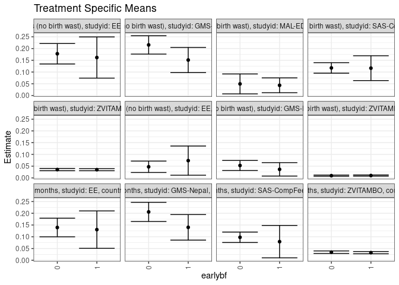

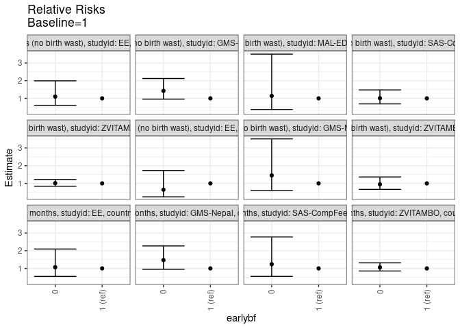

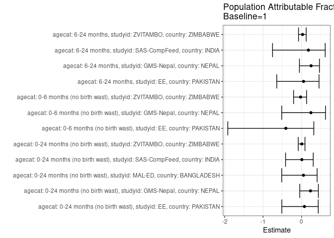

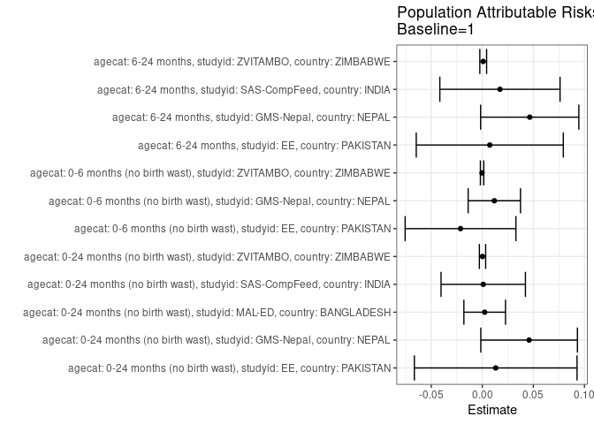

## Results Table

### Parameter: TSM

| agecat | studyid | country | intervention_level | baseline_level | estimate | ci_lower | ci_upper |
| --- | --- | --- | --- | --- | --- | --- | --- |
| 0-24 months (no birth wast) | EE | PAKISTAN | 1 | NA | 0.1617647 | 0.0741226 | 0.2494068 |
| 0-24 months (no birth wast) | EE | PAKISTAN | 0 | NA | 0.1778523 | 0.1343774 | 0.2213273 |
| 0-24 months (no birth wast) | GMS-Nepal | NEPAL | 1 | NA | 0.1511628 | 0.0975854 | 0.2047402 |
| 0-24 months (no birth wast) | GMS-Nepal | NEPAL | 0 | NA | 0.2154567 | 0.1764279 | 0.2544855 |
| 0-24 months (no birth wast) | MAL-ED | BANGLADESH | 1 | NA | 0.0434783 | 0.0119174 | 0.0750391 |
| 0-24 months (no birth wast) | MAL-ED | BANGLADESH | 0 | NA | 0.0495050 | 0.0071195 | 0.0918904 |
| 0-24 months (no birth wast) | SAS-CompFeed | INDIA | 1 | NA | 0.1165049 | 0.0636927 | 0.1693170 |
| 0-24 months (no birth wast) | SAS-CompFeed | INDIA | 0 | NA | 0.1174743 | 0.0951137 | 0.1398349 |
| 0-24 months (no birth wast) | ZVITAMBO | ZIMBABWE | 1 | NA | 0.0350742 | 0.0305920 | 0.0395563 |
| 0-24 months (no birth wast) | ZVITAMBO | ZIMBABWE | 0 | NA | 0.0355186 | 0.0306962 | 0.0403411 |
| 0-6 months (no birth wast) | EE | PAKISTAN | 1 | NA | 0.0735294 | 0.0114086 | 0.1356503 |
| 0-6 months (no birth wast) | EE | PAKISTAN | 0 | NA | 0.0472973 | 0.0230816 | 0.0715130 |
| 0-6 months (no birth wast) | GMS-Nepal | NEPAL | 1 | NA | 0.0363636 | 0.0077766 | 0.0649507 |
| 0-6 months (no birth wast) | GMS-Nepal | NEPAL | 0 | NA | 0.0527578 | 0.0312831 | 0.0742325 |
| 0-6 months (no birth wast) | ZVITAMBO | ZIMBABWE | 1 | NA | 0.0100724 | 0.0076171 | 0.0125277 |
| 0-6 months (no birth wast) | ZVITAMBO | ZIMBABWE | 0 | NA | 0.0095564 | 0.0069959 | 0.0121170 |
| 6-24 months | EE | PAKISTAN | 1 | NA | 0.1304348 | 0.0508609 | 0.2100086 |
| 6-24 months | EE | PAKISTAN | 0 | NA | 0.1394558 | 0.0998026 | 0.1791090 |
| 6-24 months | GMS-Nepal | NEPAL | 1 | NA | 0.1401274 | 0.0857795 | 0.1944752 |
| 6-24 months | GMS-Nepal | NEPAL | 0 | NA | 0.2058047 | 0.1650643 | 0.2465452 |
| 6-24 months | SAS-CompFeed | INDIA | 1 | NA | 0.0792079 | 0.0101913 | 0.1482246 |
| 6-24 months | SAS-CompFeed | INDIA | 0 | NA | 0.0978261 | 0.0756691 | 0.1199830 |
| 6-24 months | ZVITAMBO | ZIMBABWE | 1 | NA | 0.0323949 | 0.0275761 | 0.0372137 |
| 6-24 months | ZVITAMBO | ZIMBABWE | 0 | NA | 0.0343115 | 0.0289510 | 0.0396720 |

### Parameter: E(Y)

| agecat | studyid | country | intervention_level | baseline_level | estimate | ci_lower | ci_upper |
| --- | --- | --- | --- | --- | --- | --- | --- |
| 0-24 months (no birth wast) | EE | PAKISTAN | NA | NA | 0.1748634 | 0.1358949 | 0.2138319 |
| 0-24 months (no birth wast) | GMS-Nepal | NEPAL | NA | NA | 0.1969950 | 0.1651175 | 0.2288725 |
| 0-24 months (no birth wast) | MAL-ED | BANGLADESH | NA | NA | 0.0458015 | 0.0204393 | 0.0711637 |
| 0-24 months (no birth wast) | SAS-CompFeed | INDIA | NA | NA | 0.1174061 | 0.0943414 | 0.1404709 |
| 0-24 months (no birth wast) | ZVITAMBO | ZIMBABWE | NA | NA | 0.0352815 | 0.0319984 | 0.0385647 |
| 0-6 months (no birth wast) | EE | PAKISTAN | NA | NA | 0.0521978 | 0.0293166 | 0.0750791 |
| 0-6 months (no birth wast) | GMS-Nepal | NEPAL | NA | NA | 0.0481100 | 0.0307091 | 0.0655108 |
| 0-6 months (no birth wast) | ZVITAMBO | ZIMBABWE | NA | NA | 0.0098319 | 0.0080591 | 0.0116048 |
| 6-24 months | EE | PAKISTAN | NA | NA | 0.1377410 | 0.1022397 | 0.1732424 |
| 6-24 months | GMS-Nepal | NEPAL | NA | NA | 0.1865672 | 0.1535569 | 0.2195775 |
| 6-24 months | SAS-CompFeed | INDIA | NA | NA | 0.0964723 | 0.0729872 | 0.1199573 |
| 6-24 months | ZVITAMBO | ZIMBABWE | NA | NA | 0.0332779 | 0.0296928 | 0.0368630 |

### Parameter: RR

| agecat | studyid | country | intervention_level | baseline_level | estimate | ci_lower | ci_upper |
| --- | --- | --- | --- | --- | --- | --- | --- |
| 0-24 months (no birth wast) | EE | PAKISTAN | 1 | 1 | 1.0000000 | 1.0000000 | 1.000000 |
| 0-24 months (no birth wast) | EE | PAKISTAN | 0 | 1 | 1.0994509 | 0.6067927 | 1.992101 |
| 0-24 months (no birth wast) | GMS-Nepal | NEPAL | 1 | 1 | 1.0000000 | 1.0000000 | 1.000000 |
| 0-24 months (no birth wast) | GMS-Nepal | NEPAL | 0 | 1 | 1.4253288 | 0.9572990 | 2.122181 |
| 0-24 months (no birth wast) | MAL-ED | BANGLADESH | 1 | 1 | 1.0000000 | 1.0000000 | 1.000000 |
| 0-24 months (no birth wast) | MAL-ED | BANGLADESH | 0 | 1 | 1.1386139 | 0.3705824 | 3.498390 |
| 0-24 months (no birth wast) | SAS-CompFeed | INDIA | 1 | 1 | 1.0000000 | 1.0000000 | 1.000000 |
| 0-24 months (no birth wast) | SAS-CompFeed | INDIA | 0 | 1 | 1.0083211 | 0.6882899 | 1.477156 |
| 0-24 months (no birth wast) | ZVITAMBO | ZIMBABWE | 1 | 1 | 1.0000000 | 1.0000000 | 1.000000 |
| 0-24 months (no birth wast) | ZVITAMBO | ZIMBABWE | 0 | 1 | 1.0126725 | 0.8404139 | 1.220239 |
| 0-6 months (no birth wast) | EE | PAKISTAN | 1 | 1 | 1.0000000 | 1.0000000 | 1.000000 |
| 0-6 months (no birth wast) | EE | PAKISTAN | 0 | 1 | 0.6432432 | 0.2395232 | 1.727440 |
| 0-6 months (no birth wast) | GMS-Nepal | NEPAL | 1 | 1 | 1.0000000 | 1.0000000 | 1.000000 |
| 0-6 months (no birth wast) | GMS-Nepal | NEPAL | 0 | 1 | 1.4508393 | 0.5986187 | 3.516320 |
| 0-6 months (no birth wast) | ZVITAMBO | ZIMBABWE | 1 | 1 | 1.0000000 | 1.0000000 | 1.000000 |
| 0-6 months (no birth wast) | ZVITAMBO | ZIMBABWE | 0 | 1 | 0.9487750 | 0.6604576 | 1.362955 |
| 6-24 months | EE | PAKISTAN | 1 | 1 | 1.0000000 | 1.0000000 | 1.000000 |
| 6-24 months | EE | PAKISTAN | 0 | 1 | 1.0691610 | 0.5454185 | 2.095831 |
| 6-24 months | GMS-Nepal | NEPAL | 1 | 1 | 1.0000000 | 1.0000000 | 1.000000 |
| 6-24 months | GMS-Nepal | NEPAL | 0 | 1 | 1.4686975 | 0.9502142 | 2.270091 |
| 6-24 months | SAS-CompFeed | INDIA | 1 | 1 | 1.0000000 | 1.0000000 | 1.000000 |
| 6-24 months | SAS-CompFeed | INDIA | 0 | 1 | 1.2350543 | 0.5496390 | 2.775202 |
| 6-24 months | ZVITAMBO | ZIMBABWE | 1 | 1 | 1.0000000 | 1.0000000 | 1.000000 |
| 6-24 months | ZVITAMBO | ZIMBABWE | 0 | 1 | 1.0591637 | 0.8536437 | 1.314164 |

### Parameter: PAR

| agecat | studyid | country | intervention_level | baseline_level | estimate | ci_lower | ci_upper |
| --- | --- | --- | --- | --- | --- | --- | --- |
| 0-24 months (no birth wast) | EE | PAKISTAN | 1 | NA | 0.0130987 | -0.0665599 | 0.0927572 |
| 0-24 months (no birth wast) | GMS-Nepal | NEPAL | 1 | NA | 0.0458322 | -0.0014773 | 0.0931417 |
| 0-24 months (no birth wast) | MAL-ED | BANGLADESH | 1 | NA | 0.0023233 | -0.0180515 | 0.0226980 |
| 0-24 months (no birth wast) | SAS-CompFeed | INDIA | 1 | NA | 0.0009013 | -0.0404144 | 0.0422170 |
| 0-24 months (no birth wast) | ZVITAMBO | ZIMBABWE | 1 | NA | 0.0002073 | -0.0028639 | 0.0032786 |
| 0-6 months (no birth wast) | EE | PAKISTAN | 1 | NA | -0.0213316 | -0.0755601 | 0.0328969 |
| 0-6 months (no birth wast) | GMS-Nepal | NEPAL | 1 | NA | 0.0117463 | -0.0138786 | 0.0373713 |
| 0-6 months (no birth wast) | ZVITAMBO | ZIMBABWE | 1 | NA | -0.0002405 | -0.0018938 | 0.0014129 |
| 6-24 months | EE | PAKISTAN | 1 | NA | 0.0073063 | -0.0647016 | 0.0793141 |
| 6-24 months | GMS-Nepal | NEPAL | 1 | NA | 0.0464398 | -0.0016543 | 0.0945338 |
| 6-24 months | SAS-CompFeed | INDIA | 1 | NA | 0.0172644 | -0.0415921 | 0.0761208 |
| 6-24 months | ZVITAMBO | ZIMBABWE | 1 | NA | 0.0008830 | -0.0024378 | 0.0042037 |

### Parameter: PAF

| agecat | studyid | country | intervention_level | baseline_level | estimate | ci_lower | ci_upper |
| --- | --- | --- | --- | --- | --- | --- | --- |
| 0-24 months (no birth wast) | EE | PAKISTAN | 1 | NA | 0.0749081 | -0.5134193 | 0.4345288 |
| 0-24 months (no birth wast) | GMS-Nepal | NEPAL | 1 | NA | 0.2326567 | -0.0468048 | 0.4375114 |
| 0-24 months (no birth wast) | MAL-ED | BANGLADESH | 1 | NA | 0.0507246 | -0.5154506 | 0.4053757 |
| 0-24 months (no birth wast) | SAS-CompFeed | INDIA | 1 | NA | 0.0076767 | -0.4153285 | 0.3042565 |
| 0-24 months (no birth wast) | ZVITAMBO | ZIMBABWE | 1 | NA | 0.0058769 | -0.0850970 | 0.0892235 |
| 0-6 months (no birth wast) | EE | PAKISTAN | 1 | NA | -0.4086687 | -1.9178010 | 0.3199167 |
| 0-6 months (no birth wast) | GMS-Nepal | NEPAL | 1 | NA | 0.2441558 | -0.5155273 | 0.6230352 |
| 0-6 months (no birth wast) | ZVITAMBO | ZIMBABWE | 1 | NA | -0.0244573 | -0.2071410 | 0.1305798 |
| 6-24 months | EE | PAKISTAN | 1 | NA | 0.0530435 | -0.6444839 | 0.4547064 |
| 6-24 months | GMS-Nepal | NEPAL | 1 | NA | 0.2489172 | -0.0551448 | 0.4653574 |
| 6-24 months | SAS-CompFeed | INDIA | 1 | NA | 0.1789567 | -0.7540977 | 0.6156930 |
| 6-24 months | ZVITAMBO | ZIMBABWE | 1 | NA | 0.0265330 | -0.0785071 | 0.1213428 |